# Batting to Win

Angelica Morales & Gabriel Rodriguez

5/10/2022

# Introduction

Often referred to as “America’s Pastime” , baseball is part of this country’s culture, spanning over 145 years of it’s history. During which time, baseball data has evolved from simple number gathering, to a much more complex form of analysis known today as “sabermetrics” that strives to evaluate and compare player performance using several different variables.

What this project hopes to accomplish is to observe the trends in two of the more traditional baseball batting statistics: batting average and home runs to determine how they’ve changed through the sports history, and also what role they play in deciding the winning and losing World Series teams.

We will look at the trends of these statistics through baseball’s regular season as well as the World Series. We will then examine the relationship between team batting average and total home runs hit by teams that play in the World Series.

Any trends will help us predict what kind of batting average and home run numbers we can see in future regular seasons as well as World Series’. Any relationship between team batting average and total home runs hit, will help us determine which of those statistics are more important to winning the World Series.

## Packages Used

```r
library(tidyverse)
library(ggplot2)
library(plotly)
library(dbplyr)
library(patchwork)
library(ggthemes)
library(Lahman)
```

## Historical Context

The World Series is the annual championship series played between the two respective league (American League and National League) champions in Major League Baseball. Winning the World Series is what every team and player strive for at the start of the season, and is therefore deemed the greatest achievement in all of baseball.

Although first played 1884, the modern era of the World Series is considered to being in 1903, when the series became a “best-of-7 game series”. We will only be looking at data from 1903-2020 (Lahman Database only contains data up to 2020). There have been a total of 116 World Series played between these years (the exceptions being: 1904, and 1994).

```
## # A tibble: 1 x 2
## # Groups:   round [1]
##   round     n
##   <chr> <int>
## 1 WS      116
```

## Variables Used

To better understand the data we will be exploring, and why we chose it, let’s define our variables. Two of the most traditional statistics in baseball, are the Home Run, and Batting Average.

A **home run** occurs when a batter hits a fair ball and scores on the play without being put out or without benefit of an error.

**Batting Average** is the average performance of a batter, expressed as a ratio of a batter’s safe hits per official times at bat. It is calculated by dividing the number of hits by the number of at bats.

**Relationship Between Home Runs and Batting Average**

The relationship between Home Runs and Batting average, is as old as baseball itself. There has always been a debate on which is more beneficial: hitting a greater number of home runs, or hitting for a higher batting average.

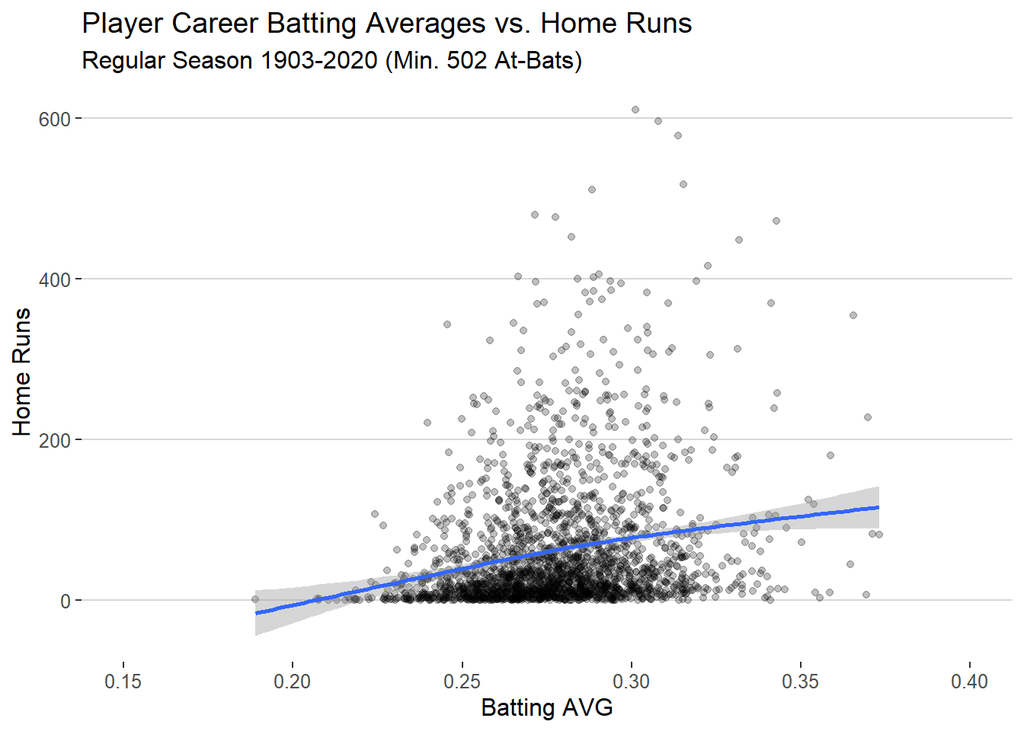

This graph shows us the relationship between player’s career batting average and home runs hit; and although there is a positive relationship between the two, many batters with career averages over or around .300 (what is considered a great batting average) hit less than 200 career home runs. On the other hand, a good majority of players who hit more than 200 career home runs have batting averages under .300.

## Data Used

We sourced our data from the ‘Lahman’ Baseball Database. Sean Lahman, the creator of the database is an investigative journalist, a sports column writer, author, and Data Projects Manager for the Society of American Baseball Research. The database is composed of 26 tables that each consist of unique baseball data ranging from baseball and pitching statistics for individual players, to salary information, and postseason results. The package is available in ‘R’.

- **‘Batting’ Table**

From the database, we worked with data found in the ‘Batting Table’, which contains regular season batting statistics for individual players from 1871 to 2020.

```
## # A tibble: 108,789 x 22
##    playerID  yearID stint teamID lgID      G    AB     R     H   X2B   X3B    HR
##    <chr>      <int> <int> <fct>  <fct> <int> <int> <int> <int> <int> <int> <int>
##  1 abercda01   1871     1 TRO    NA        1     4     0     0     0     0     0
##  2 addybo01    1871     1 RC1    NA       25   118    30    32     6     0     0
##  3 allisar01   1871     1 CL1    NA       29   137    28    40     4     5     0
##  4 allisdo01   1871     1 WS3    NA       27   133    28    44    10     2     2
##  5 ansonca01   1871     1 RC1    NA       25   120    29    39    11     3     0
##  6 armstbo01   1871     1 FW1    NA       12    49     9    11     2     1     0
##  7 barkeal01   1871     1 RC1    NA        1     4     0     1     0     0     0
##  8 barnero01   1871     1 BS1    NA       31   157    66    63    10     9     0
##  9 barrebi01   1871     1 FW1    NA        1     5     1     1     1     0     0
## 10 barrofr01   1871     1 BS1    NA       18    86    13    13     2     1     0
## # ... with 108,779 more rows, and 10 more variables: RBI <int>, SB <int>,
## #   CS <int>, BB <int>, SO <int>, IBB <int>, HBP <int>, SH <int>, SF <int>,
## #   GIDP <int>
```

- **‘BattingPost’ Table**

The ‘BattingPost’ table, contains individual players batting statistics for every different playoff round played between 1884 and 2020.

```
## # A tibble: 15,460 x 22
##    yearID round playerID  teamID lgID      G    AB     R     H   X2B   X3B    HR
##     <int> <chr> <chr>     <fct>  <fct> <int> <int> <int> <int> <int> <int> <int>
##  1   1884 WS    becanbu01 NY4    AA        1     2     0     1     0     0     0
##  2   1884 WS    bradyst01 NY4    AA        3    10     1     0     0     0     0
##  3   1884 WS    carrocl01 PRO    NL        3    10     2     1     0     0     0
##  4   1884 WS    dennyje01 PRO    NL        3     9     3     4     0     1     1
##  5   1884 WS    esterdu01 NY4    AA        3    10     0     3     1     0     0
##  6   1884 WS    farreja02 PRO    NL        3     9     3     4     2     0     0
##  7   1884 WS    forstto01 NY4    AA        1     3     0     0     0     0     0
##  8   1884 WS    gilliba01 PRO    NL        3     9     3     4     2     0     0
##  9   1884 WS    hinespa01 PRO    NL        3     8     5     2     0     0     0
## 10   1884 WS    irwinar01 PRO    NL        3     9     3     2     0     1     0
## # ... with 15,450 more rows, and 10 more variables: RBI <int>, SB <int>,
## #   CS <int>, BB <int>, SO <int>, IBB <int>, HBP <int>, SH <int>, SF <int>,
## #   GIDP <int>
```

- **‘SeriesPost’ Table**

Finally, we also used the ‘SeriesPost’ table which contains data regarding playoff round results.

```
## # A tibble: 358 x 9
##    yearID round teamIDwinner lgIDwinner teamIDloser lgIDloser  wins losses  ties
##     <int> <chr> <fct>        <fct>      <fct>       <fct>     <int>  <int> <int>
##  1   1884 WS    PRO          NL         NY4         AA            3      0     0
##  2   1885 WS    CHN          NL         SL4         AA            3      3     1
##  3   1886 WS    SL4          AA         CHN         NL            4      2     0
##  4   1887 WS    DTN          NL         SL4         AA           10      5     0
##  5   1888 WS    NY1          NL         SL4         AA            6      4     0
##  6   1889 WS    NY1          NL         BR3         AA            6      3     0
##  7   1890 WS    BRO          NL         LS2         AA            3      3     1
##  8   1892 CS    BSN          NL         CL4         NL            5      0     1
##  9   1903 WS    BOS          AL         PIT         NL            5      3     0
## 10   1905 WS    NY1          NL         PHA         AL            4      1     0
## # ... with 348 more rows
```

## Data Cleaning/Tidying

Our data cleaning and tidying consisted, first of filtering all our data for only data from starting year 1903. We also added batting average columns (there is no batting average statistic in the ‘Batting’ or ‘BattingPost’ table), and grouped all our observations by ‘yearID’, and ‘teamID’ to get team batting information for every season. For the ‘SeriesPost’ table we filtered out all observations that weren’t World Series Results, added a ‘Won/Lost’ column, and finally we merged the regular season and post season batting data to the World Series Results.

We ended with 3: “Regular Season Batting”, “World Series Batting”, and “Regular/World Series Batting” with series results.

- **‘RegSeason_Batting’ Table**

Includes regular season team batting averages and total home runs hit for every year and team from 1903-2020.

```
## # A tibble: 2,524 x 6
##    yearID teamID lgID  Total_Reg_HR Team_Reg_HR_AVG Team_Reg_AVG
##     <int> <fct>  <fct>        <int>           <dbl>        <dbl>
##  1   1903 BOS    AL              48        0.00650         0.265
##  2   1903 BRO    NL              15        0.00307         0.225
##  3   1903 BSN    NL              25        0.00449         0.227
##  4   1903 CHA    AL              14        0.00191         0.231
##  5   1903 CHN    NL               9        0.000715        0.198
##  6   1903 CIN    NL              28        0.00223         0.237
##  7   1903 CLE    AL              31        0.00248         0.185
##  8   1903 DET    AL              12        0.00128         0.224
##  9   1903 NY1    NL              20        0.00250         0.226
## 10   1903 NYA    AL              18        0.00333         0.187
## # ... with 2,514 more rows
```

- **‘WS_Batting’ Table**

Includes World Series team batting averages and total home runs hit for every year and team from 1903-2020.

```
## # A tibble: 232 x 8
##    yearID teamID lgID  Total_WS_HR Team_WS_HR_AVG Team_WS_AVG Series_Length
##     <int> <fct>  <fct>       <int>          <dbl>       <dbl>         <int>
##  1   1903 BOS    AL              2        0.00490       0.195             8
##  2   1903 PIT    NL              1        0.00238       0.190             8
##  3   1905 NY1    NL              0        0             0.183             5
##  4   1905 PHA    AL              0        0             0.128             5
##  5   1906 CHA    AL              0        0             0.131             6
##  6   1906 CHN    NL              0        0             0.153             6
##  7   1907 CHN    NL              0        0             0.193             4
##  8   1907 DET    AL              0        0             0.186             4
##  9   1908 CHN    NL              1        0.00405       0.216             5
## 10   1908 DET    AL              0        0             0.198             5
## # ... with 222 more rows, and 1 more variable: `Won/Lost` <chr>
```

- **‘Reg_WS_Batting’ Table**

Includes regular season/World Series team batting averages and total home runs hit only for teams that made the World Series, as well as whether the team won or lost the series.

```
## # A tibble: 232 x 11
##    yearID teamID lgID  Total_WS_HR Team_WS_HR_AVG Team_WS_AVG Series_Length
##     <int> <fct>  <fct>       <int>          <dbl>       <dbl>         <int>
##  1   1903 BOS    AL              2        0.00490       0.195             8
##  2   1903 PIT    NL              1        0.00238       0.190             8
##  3   1905 NY1    NL              0        0             0.183             5
##  4   1905 PHA    AL              0        0             0.128             5
##  5   1906 CHA    AL              0        0             0.131             6
##  6   1906 CHN    NL              0        0             0.153             6
##  7   1907 CHN    NL              0        0             0.193             4
##  8   1907 DET    AL              0        0             0.186             4
##  9   1908 CHN    NL              1        0.00405       0.216             5
## 10   1908 DET    AL              0        0             0.198             5
## # ... with 222 more rows, and 4 more variables: `Won/Lost` <chr>,
## #   Total_Reg_HR <int>, Team_Reg_HR_AVG <dbl>, Team_Reg_AVG <dbl>
```

# Regular Season/World Series Trends

## Regular Season Home Runs

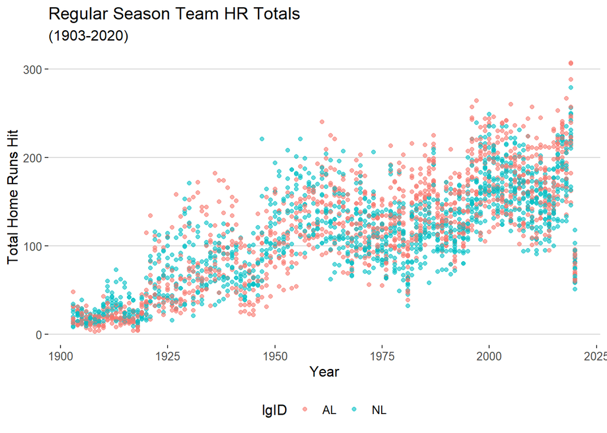

Our first graph shows regular season team home run totals. An increase in the number of home runs being hit can be attributed to different team expansions that have occurred through the decades which has seen the number of baseball teams increase from 16 teams in 1903 to 30 teams currently.

The last expansion happened in 1998 and we continue to see an increasing trend in home runs being hit. It should also be noted that the number of total home runs hit is much lower in 2020. This can be attributed to the shortened season that year, in which only 60 regular season games were played because of the pandemic.

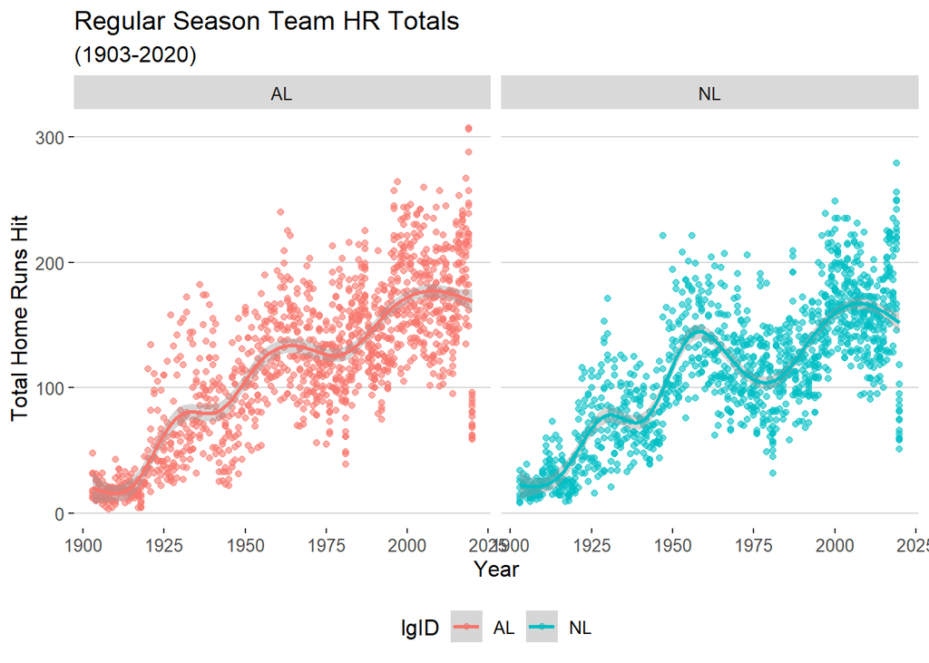

Both the American League and National League have seen similar increase in total home runs being hit. American League totals are higher overall when compared to National League totals however, and this is likely due to the fact that the American League incorporates a “designated hitter” to hit in place of the pitcher in the batting order. This makes it that there is another player in the batting order that specializes in hitting as opposed to pitching, and therefore increases home run numbers for that team.

## Regular Season Batting Average

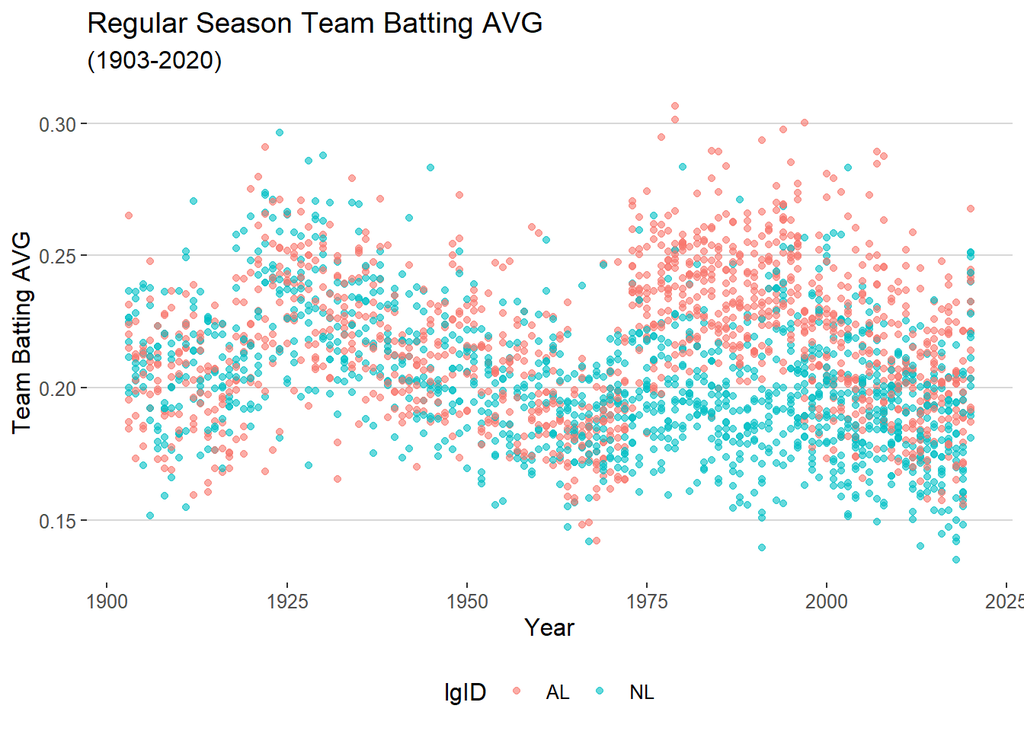

When we look at regular season team batting averages, we don’t see a defined trend initially, but looking at each league independently we can see the team batting averages for the American League, are much more varied when compared to the National League after the early 1970’s.

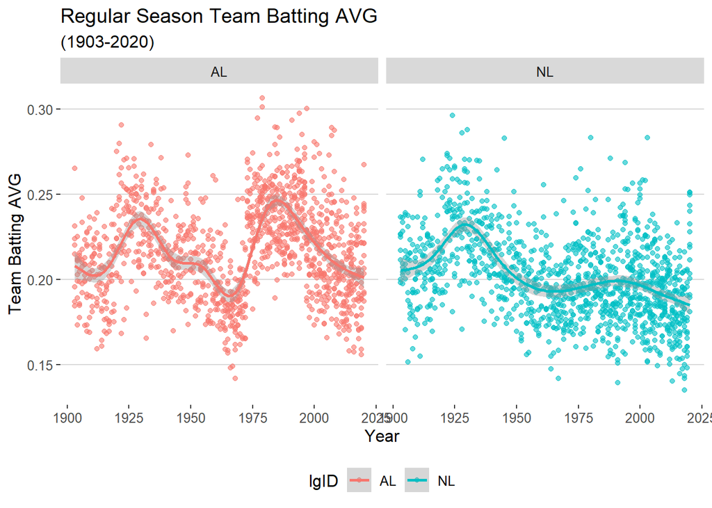

Batting averages increased substantially for the American League from the early 1970’s all the ways to the late 80’s followed by a substantial decrease. Again we can attribute this to the designated hitter being adopted by the American League. Batting average also on the decrease from early 90’s onward. Batting averages, for the American League ARE higher overall when compared to the National League.

## World Series Home Runs

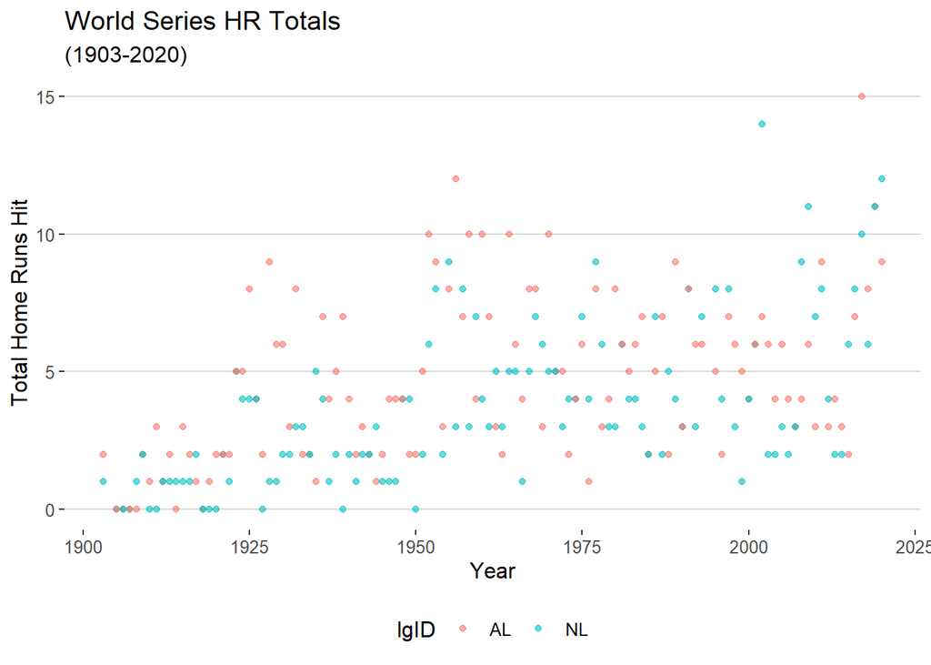

We can see from this first graph that during the first 20 years of the World Series most teams hit less than 5 total home runs, with quite a few hitting zero home runs. However, every single team to play in the world series after 1950 has hit at least one home run. During the last 20 years we can see more teams staring to hit more than 10 home runs, indicating that home runs are on the rise.

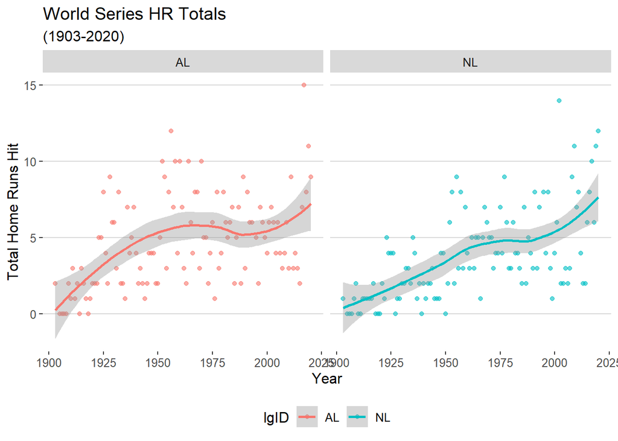

Faceting the graph to look at total home runs hit by each league, and adding a trend line, we can see that total home runs are up for both leagues at a very similar rate. In this instance, the designated hitter (which we have seen make a difference in total home runs hit in the regular season between the American League and National League) does not have much impact. For World Series games played, the designated hitter is added or removed according to the the league that the home team belongs to. There is no benefit to one particular team.

## Regular Season HR vs. World Series Home Runs

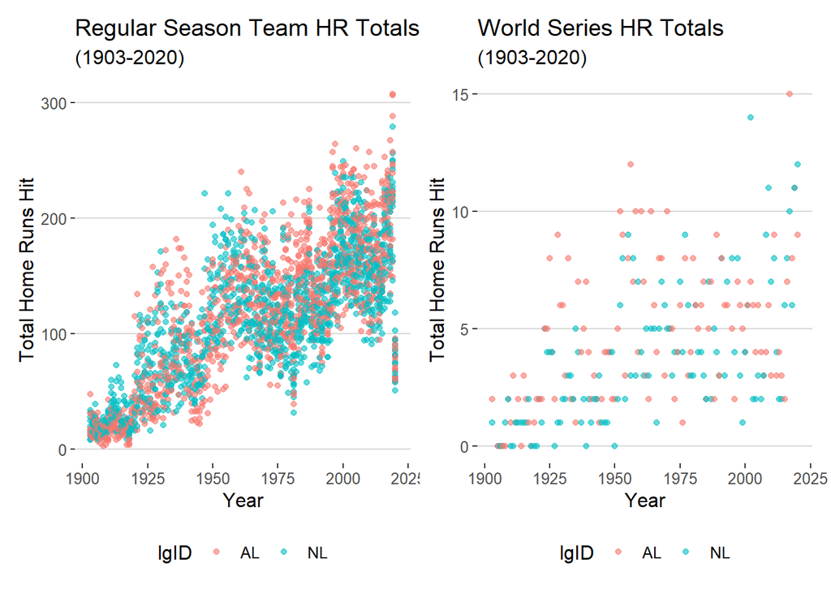

Comparing the graphs for trends in total home runs hit in the regular season versus the World Series we can see that both follow a similar increase. As mentioned previously, we can attribute the increase in home runs during the regular season to teams being added throughout the years. We also see an increase in home runs being hit during the World Series, this may be due to a number of other variables like advances in training regimens, batting mechanics, technology, etc.

## World Series Batting Average

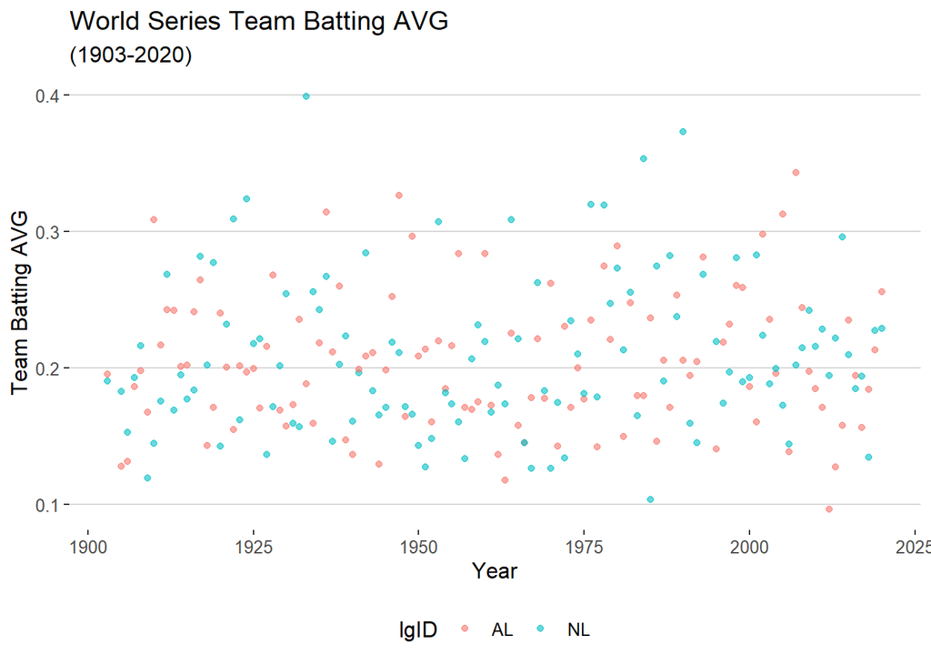

Now, we’ll look at world series team batting averages. Only 14 teams have had a batting average above .300, 9 being National League teams, and 5 being American League teams.

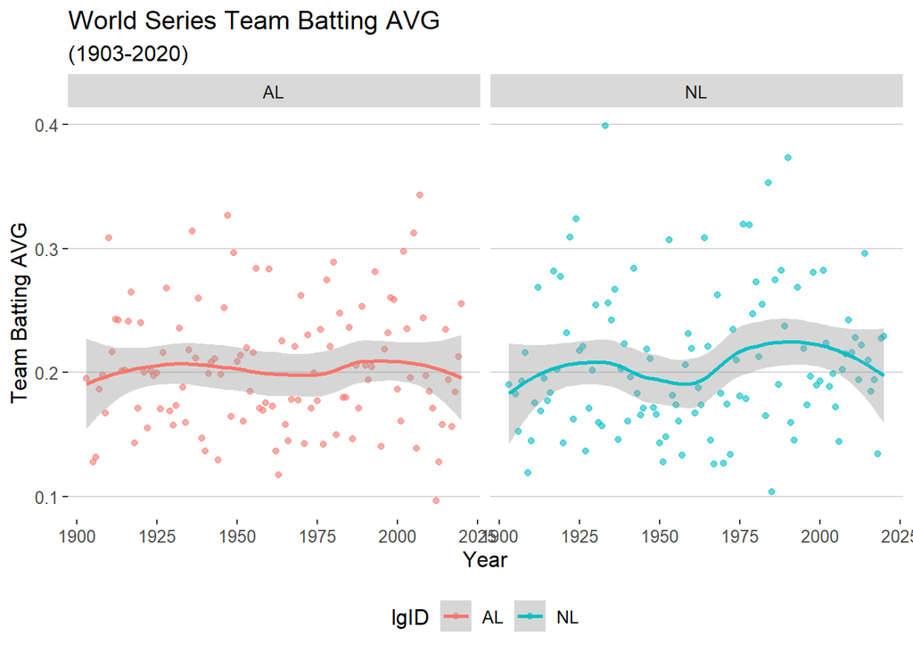

We can get a better look if we split the teams up by their respective league. For the American League, teams have batted for a .200 average fairly consistently through time. We see more variation for teams in the National League, but we have seen them have a higher batting average than the American League overall since right around 1975.

## Regular Season AVG vs. World Series AVG

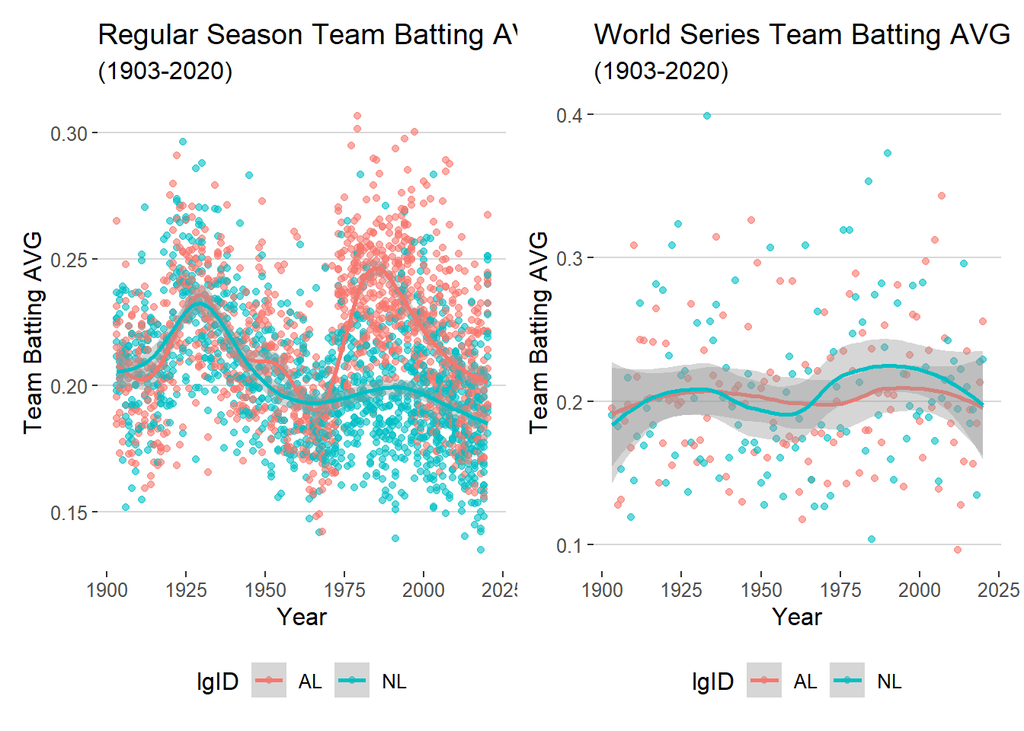

Comparing regular season team batting averages to world series team batting averages, we see that regular season batting average has a lot more variation throughout the las century, with the American league having even greater variation than the national league. As low as .190 in the late 1960’s to as high as .240 in the late 1980’s. For World Series team batting averages, they have tended to stay more consistent, hovering around .200. However, regular season and World Series team batting averages are currently trending down.

# Winning vs. Losing Teams

## Winning/Losing Team WS Home Runs

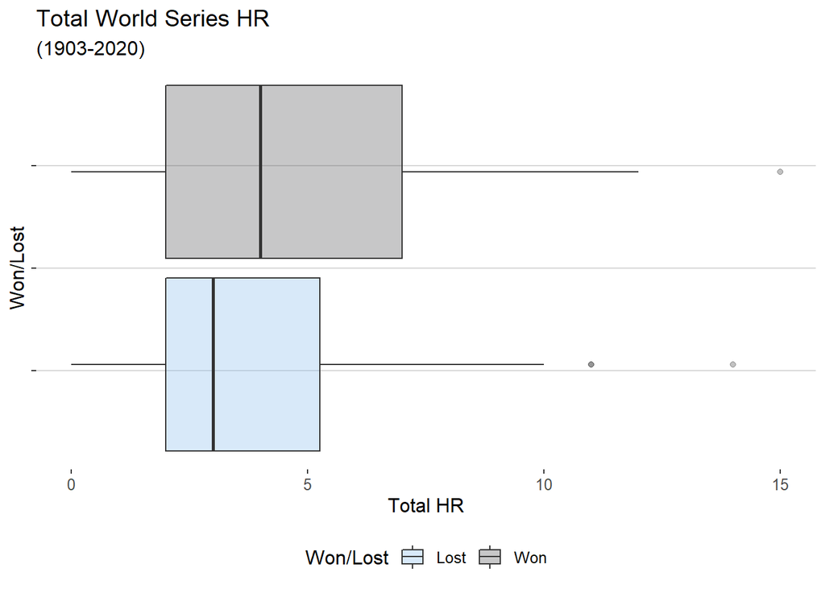

## Winning/Losing Team HR Density

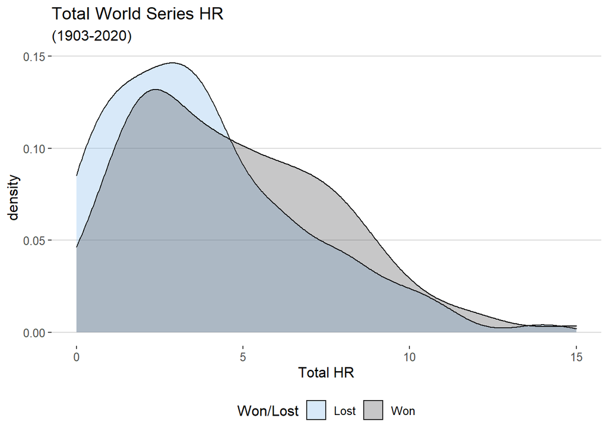

A density plot of this same data shows us that winning teams are hitting 5 or more home runs more frequently, than the losing teams. And in contrast the losing teams are hitting less than 5 home runs more frequently than the winning team. We can determine that hitting 5 or more total home runs during the World Series increases a teams chances of winning.

## Winning/Losing Team WS Batting AVG

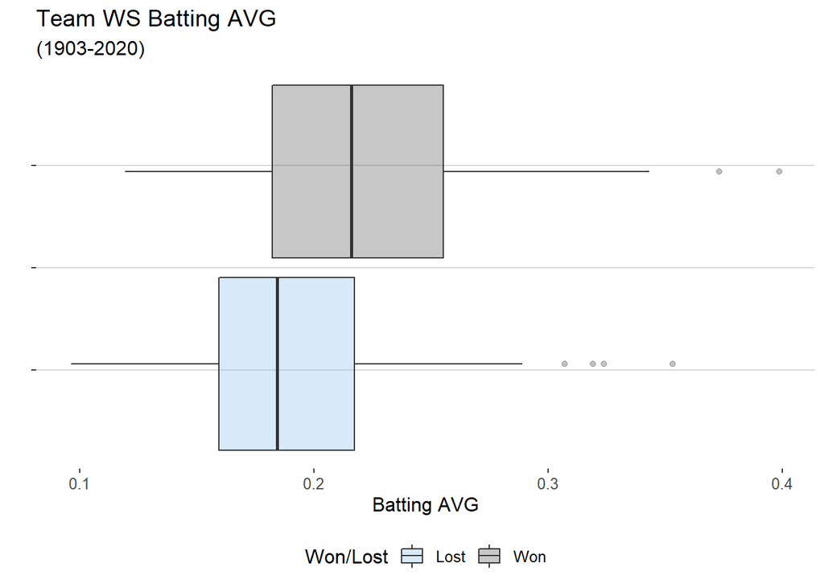

Teams that WON the World Series: - higher minimum, median, and maximum world series team batting averages - even the outliers are higher - More than 50 % of teams are batting higher than a .200 batting average Teams that LOST the World Series - Maximum batting average doesn’t even reach .300 and even the maximum outliers, only one exceeds the maximum of the winning teams batting average - More than half of the losing teams are batting lower than a .200 average

## Winning/Losing Teams AVG Density

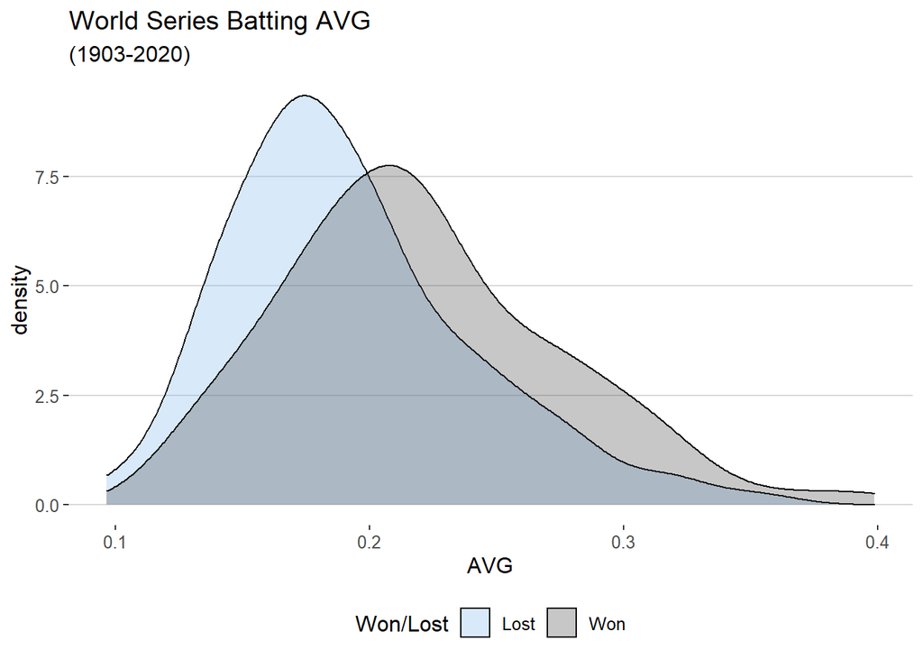

Winning teams are batting for an average higher than .200 more frequently than the losing teams. Losing teams are batting for an average less than .200 more frequently than the winning teams.

## Summary of Results

As far as trends in total home runs being hit during the regular season, we have seen an increase in home runs and are likely to continue to see an increase in the future.

Trends for team batting averages, however, have been more unpredictable, but we are currently in a decreasing trend. Will we see batting averages continue to fall? It’s hard to tell from this data exploration.

Hitting home runs is the only way in baseball that guarantees at least one run will score, however, higher batting averages produce more opportunities for scoring. A higher batting average will also result in success given those scoring opportunities, and when it comes to winning the World Series, producing as many scoring opportunities as possible is slightly more advantageous than hitting home runs.

## Limitations of our Analysis

There are many other variables to consider. There’s a plethora of other traditional batting statistics and advanced batting statistics as well, many of which have just been discovered in the last few years.

We also have to consider that baseball is not just about batting. On the other side of batting, we have pitching, which has just has many variables as batting, if not more. There is even “fielding” statistics, “batter vs pitcher” statistics, “base running” statistics, “stadium” statistics, the list goes on.

Any one of these variables, or combination of them may be better at looking for our answers. And of course, there is always the element of luck. For all the data and statistics in baseball , sometimes the odds are defied, and the improbable happens.